# Projet The multi-feature digit dataset Pixel

STA211 - 2019/2020

L.RANT

04 juillet, 2020

# 1 Introduction

Ce jeu de données est constitué de caractéristiques de chiffres manuscrits (`0'--`9’) extrait d’une collection de cartes d’utilité publique néerlandaises. Les modèles ont été numérisés en images binaire. Ces chiffres sont représentés par les six des ensembles de fonctionnalités suivantes :

1. mfeat-fou: 76 Fourier coefficients of the character shapes;
2. mfeat-fac: 216 profile correlations;
3. mfeat-kar: 64 Karhunen-Love coefficients;
4. mfeat-pix: 240 pixel averages in 2 x 3 windows;
5. mfeat-zer: 47 Zernike moments;
6. mfeat-mor: 6 morphological features.

Nous n’avons pas de valeurs manquantes. La problématique: en analysant les 6 groupes séparement on gardera dans chaque groupe les variables qui influence le plus le choix des classes et cherchera le meilleur algorithme qui peut predire les classes.

# 2 Importation des données

```
##    class pix_1 pix_2 pix_3 pix_4 pix_5 pix_6 pix_7 pix_8 pix_9 pix_10 pix_11
## 1      0     0     3     4     4     4     4     4     4     4      4      4
## 2      0     0     0     3     6     6     6     6     6     6      5      4
## 3      0     0     0     0     2     5     5     4     6     4      4      1
## 4      0     0     0     0     0     0     0     0     0     1      3      5
## 5      0     0     5     6     6     6     6     6     6     6      5      2
## 6      0     0     0     0     0     1     3     4     4     4      3      2
## 7      0     0     0     0     1     5     6     6     6     6      5      3
## 8      0     0     5     6     6     6     6     6     6     6      6      4
## 9      0     0     3     4     6     6     5     2     0     0      0      0
## 10     0     0     3     6     6     6     6     6     6     5      1      0
##    pix_12 pix_13 pix_14 pix_15 pix_16 pix_17 pix_18 pix_19 pix_20 pix_21 pix_22
## 1       1      0      0      0      0      6      6      6      6      6      4
## 2       3      0      0      0      0      3      6      6      6      6      6
## 3       0      0      0      0      0      1      5      6      6      6      6
```

[output cut: 260 more lines]

# 3 Aperçu général

```
##
##  factor numeric
##       1     240
```

```
## [1] 1500
```

```
## [1] 241
```

```
## [1] 150
```

```
## [1] 150
```

# 4 Exploration

## 4.1 Analyse univariée

Representation des 240 groupes de pixels: sur chaque groupe, supprimer ce qui ne servent à rien.on supprime les colonnes selon le résultat du fichier excel sélection de variables

## 4.2 Analyse bivariée

1. pix

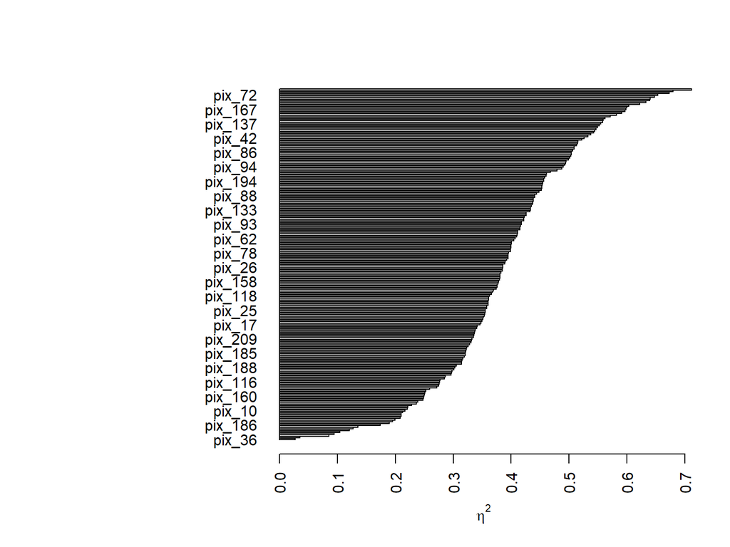

```
##   pix_153   pix_138    pix_57    pix_72   pix_152   pix_168   pix_139   pix_154
## 0.7113043 0.6790212 0.6727874 0.6534527 0.6477325 0.6397767 0.6393719 0.6325938
##    pix_58   pix_123
## 0.6222215 0.6032054
```

```
##     pix_36     pix_37    pix_204    pix_205    pix_203    pix_202    pix_131
## 0.02720639 0.03493618 0.08567808 0.09472063 0.10449521 0.12044912 0.12727255
##     pix_38    pix_186     pix_51
## 0.13499050 0.17389801 0.18931691
```

## 4.3 Analyse multivariée

### 4.3.1 Analyse factorielle

### 4.3.2 ACP sur les données quantitatives

Transformation de variables

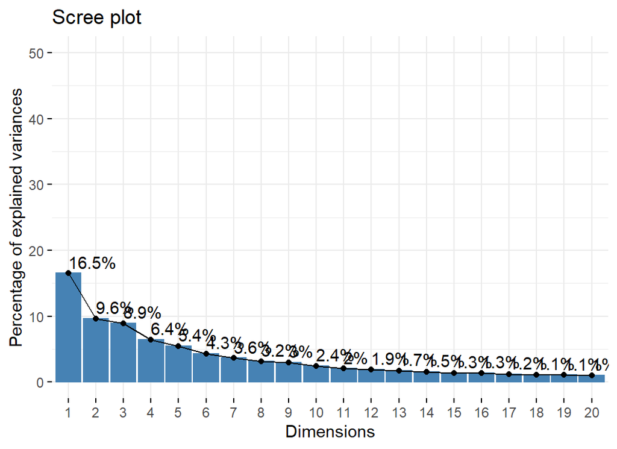

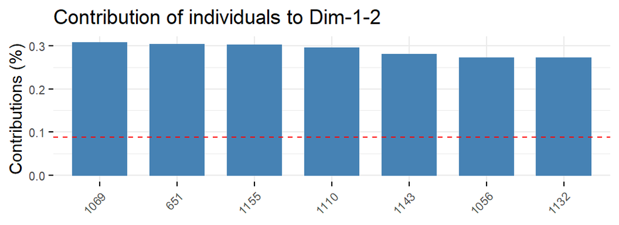

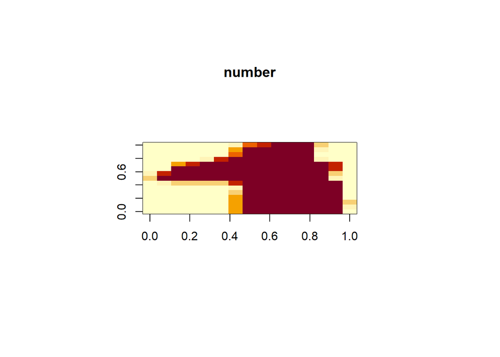

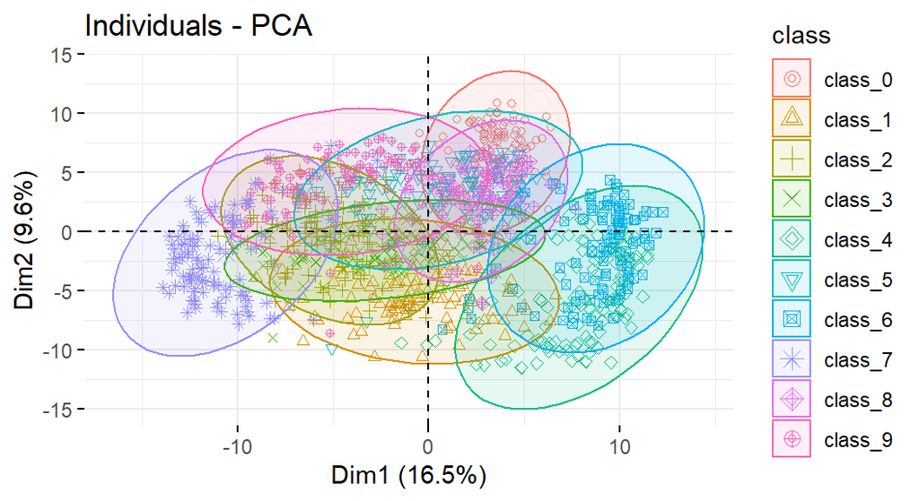

Exploitation de l’acp garder les 50 premieres composante principales

```
## Importance of components:
##                            PC1     PC2      PC3     PC4     PC5     PC6     PC7
## Standard deviation     16.2462 12.4069 11.95148 9.82256 9.18245 7.87848 7.37105
## Proportion of Variance  0.1783  0.1040  0.09651 0.06519 0.05697 0.04194 0.03671
## Cumulative Proportion   0.1783  0.2823  0.37885 0.44405 0.50102 0.54296 0.57967
##                            PC8     PC9    PC10    PC11    PC12    PC13   PC14
## Standard deviation     6.88477 6.62678 5.93165 5.27942 5.01733 4.79990 4.6481
## Proportion of Variance 0.03203 0.02967 0.02377 0.01883 0.01701 0.01557 0.0146
## Cumulative Proportion  0.61169 0.64137 0.66514 0.68397 0.70098 0.71655 0.7311
##                           PC15    PC16    PC17    PC18    PC19    PC20    PC21
## Standard deviation     4.35925 4.30979 3.95707 3.78329 3.69746 3.63423 3.41547
## Proportion of Variance 0.01284 0.01255 0.01058 0.00967 0.00924 0.00892 0.00788
## Cumulative Proportion  0.74398 0.75654 0.76712 0.77679 0.78602 0.79495 0.80283
##                           PC22    PC23   PC24    PC25    PC26    PC27    PC28
## Standard deviation     3.34112 3.15763 3.1261 2.92363 2.88227 2.82266 2.64167
## Proportion of Variance 0.00754 0.00674 0.0066 0.00578 0.00561 0.00538 0.00472
## Cumulative Proportion  0.81037 0.81711 0.8237 0.82949 0.83510 0.84048 0.84520
##                           PC29    PC30   PC31    PC32    PC33    PC34    PC35
## Standard deviation     2.53246 2.47004 2.4323 2.32352 2.29095 2.25418 2.15915
## Proportion of Variance 0.00433 0.00412 0.0040 0.00365 0.00355 0.00343 0.00315
## Cumulative Proportion  0.84953 0.85365 0.8577 0.86130 0.86485 0.86828 0.87143
##                           PC36   PC37    PC38    PC39    PC40    PC41    PC42
## Standard deviation     2.13652 2.1084 2.00353 1.97731 1.94658 1.92636 1.88226
## Proportion of Variance 0.00308 0.0030 0.00271 0.00264 0.00256 0.00251 0.00239
## Cumulative Proportion  0.87451 0.8775 0.88023 0.88287 0.88543 0.88794 0.89033
##                           PC43    PC44   PC45    PC46    PC47    PC48    PC49
## Standard deviation     1.85614 1.83292 1.8055 1.75732 1.71123 1.69259 1.68218
## Proportion of Variance 0.00233 0.00227 0.0022 0.00209 0.00198 0.00194 0.00191
## Cumulative Proportion  0.89266 0.89493 0.8971 0.89922 0.90120 0.90313 0.90505
##                           PC50    PC51    PC52    PC53    PC54    PC55   PC56
## Standard deviation     1.66331 1.65462 1.61436 1.60210 1.57443 1.56411 1.5383
## Proportion of Variance 0.00187 0.00185 0.00176 0.00173 0.00167 0.00165 0.0016
## Cumulative Proportion  0.90692 0.90876 0.91053 0.91226 0.91394 0.91559 0.9172
##                           PC57    PC58    PC59    PC60   PC61    PC62    PC63
## Standard deviation     1.51217 1.50537 1.46663 1.44998 1.4374 1.41689 1.40245
## Proportion of Variance 0.00155 0.00153 0.00145 0.00142 0.0014 0.00136 0.00133
## Cumulative Proportion  0.91873 0.92026 0.92172 0.92314 0.9245 0.92589 0.92722
##                          PC64   PC65    PC66    PC67   PC68    PC69    PC70
## Standard deviation     1.3894 1.3873 1.37731 1.37151 1.3338 1.32533 1.31292
## Proportion of Variance 0.0013 0.0013 0.00128 0.00127 0.0012 0.00119 0.00116
```

[output cut: 86 more lines]

```
## Standard deviation     0.41708 0.41416 0.40623 0.40573 0.40359 0.39570 0.3882
## Proportion of Variance 0.00012 0.00012 0.00011 0.00011 0.00011 0.00011 0.0001
## Cumulative Proportion  0.99803 0.99815 0.99826 0.99837 0.99848 0.99859 0.9987
##                         PC225  PC226  PC227  PC228   PC229   PC230   PC231
## Standard deviation     0.3858 0.3834 0.3817 0.3756 0.36407 0.36243 0.35816
## Proportion of Variance 0.0001 0.0001 0.0001 0.0001 0.00009 0.00009 0.00009
## Cumulative Proportion  0.9988 0.9989 0.9990 0.9991 0.99917 0.99926 0.99935
##                          PC232   PC233   PC234   PC235   PC236   PC237   PC238
## Standard deviation     0.34993 0.34789 0.33923 0.33563 0.32923 0.32161 0.31592
## Proportion of Variance 0.00008 0.00008 0.00008 0.00008 0.00007 0.00007 0.00007
## Cumulative Proportion  0.99943 0.99951 0.99959 0.99967 0.99974 0.99981 0.99988
##                          PC239   PC240
## Standard deviation     0.30991 0.28882
## Proportion of Variance 0.00006 0.00006
## Cumulative Proportion  0.99994 1.00000
```

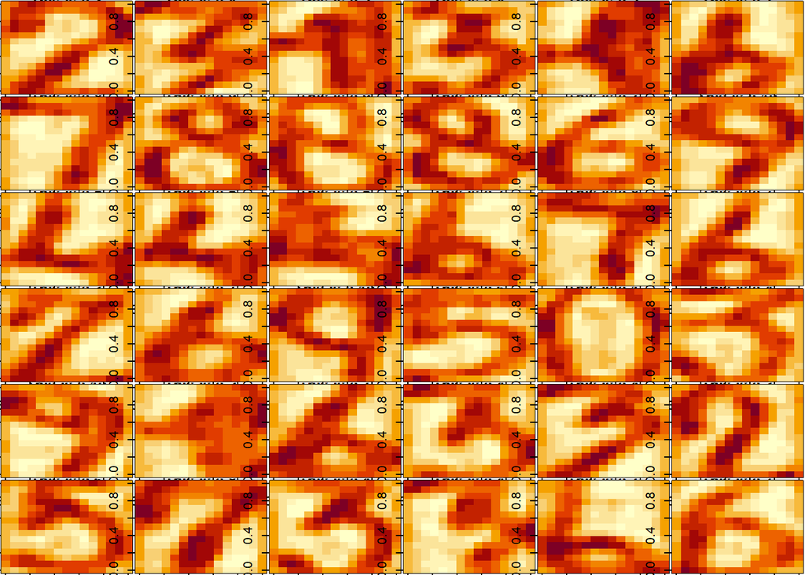

Exploitation de l’acp garder les 10 premieres composante principales. Pertes d’information mais gain de temps. Sur des gros datasets?

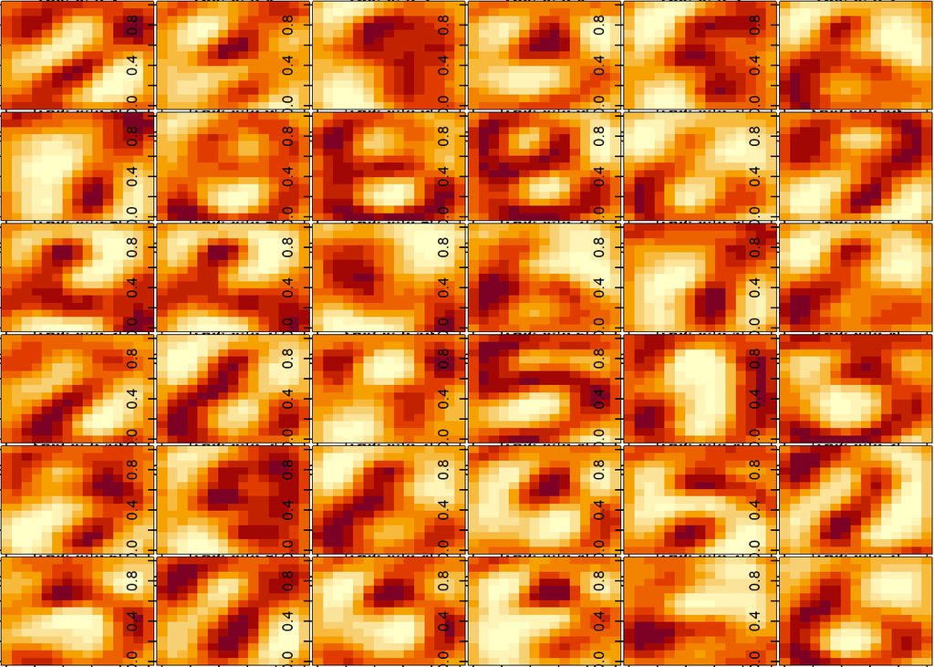

Exploitation de l’acp garder les 40 premieres composante principales. Pertes d’information mais gain de temps. Sur des gros datasets? test a 30 non concluant.

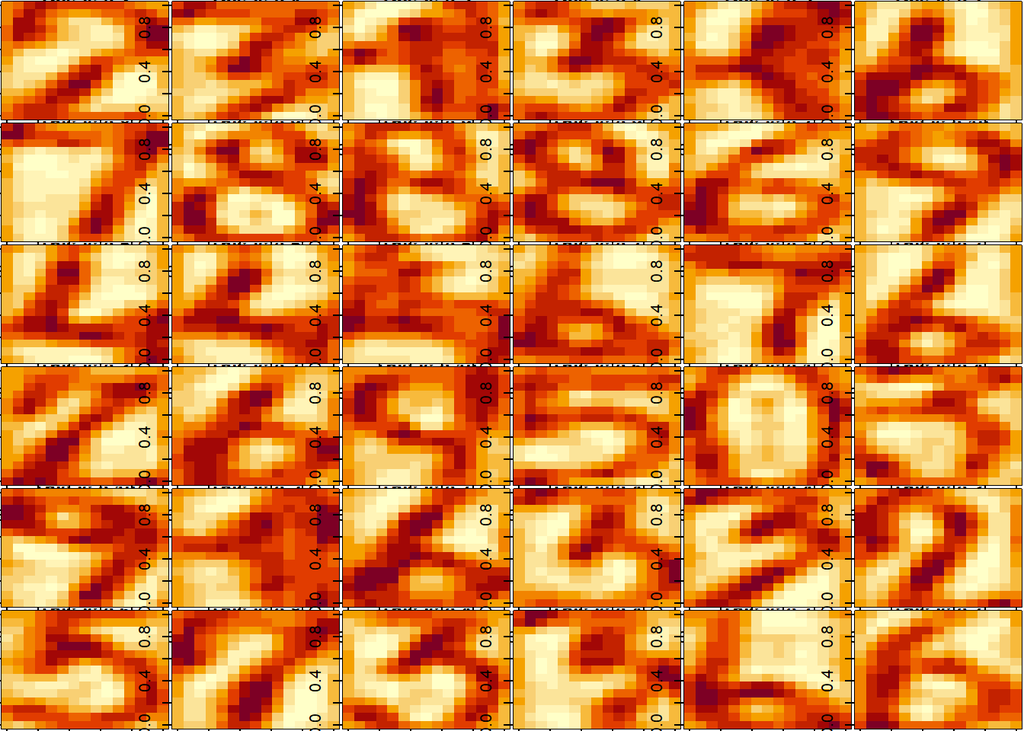

# 5 Pré-traitement

on tente la préduction avec les fameuses méthodes :

# 6 prédiction

### Arbre de décision /Tree CART

utilisation de la librairie CARET

```
## Time difference of 5.151615 secs
```

exploitataion des Résultats du CART

Voici le resultat de l’apprentissage :

```
## CART
##
## 1125 samples
##   40 predictor
##   10 classes: '0', '1', '2', '3', '4', '5', '6', '7', '8', '9'
##
## No pre-processing
## Resampling: Bootstrapped (25 reps)
## Summary of sample sizes: 1125, 1125, 1125, 1125, 1125, 1125, ...
## Resampling results across tuning parameters:
##
##   maxdepth  Accuracy   Kappa
##    1        0.2354981  0.1593970
##    2        0.3657610  0.3010154
##    3        0.3950741  0.3327888
```

[output cut: 30 more lines]

Voici les paramètres choisis :

```
## Best parameter pour maxdepth est : 16
```

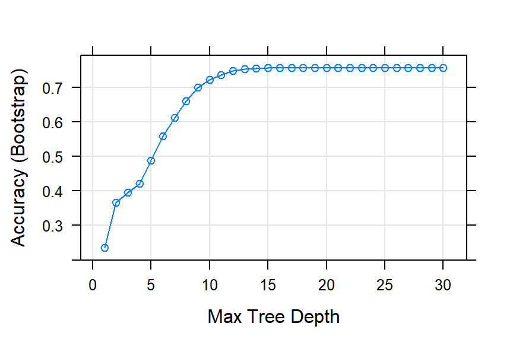

```
## Entrez 'rattle()' pour secouer, faire vibrer, et faire défiler vos données.
```

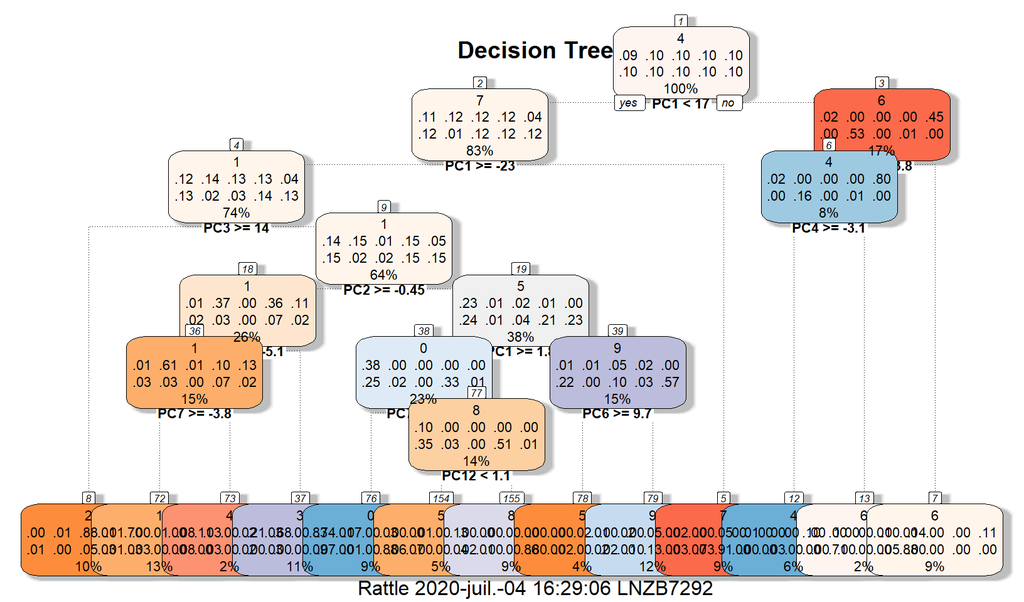

Voici le resultat de la validation:

```
##  Accuracy     Kappa
## 0.7520000 0.7242407
```

```
## Confusion Matrix and Statistics
##
##           Reference
## Prediction  0  1  2  3  4  5  6  7  8  9
##          0 34  1  0  1  1  4  0  0  1  0
##          1  1 27  2  8  3  5  0  0  2  0
##          2  0  4 28  0  0  0  0  3  0  1
##          3  0  2  0 26  0  1  1  1  6  0
##          4  1  3  0  1 21  1  2  0  0  0
##          5  1  0  0  0  0 26  2  0  2  0
##          6  1  0  0  0  8  0 31  0  0  0
##          7  0  0  2  0  0  0  0 27  0  0
##          8  6  0  0  0  0  1  1  0 25  0
##          9  0  0  7  2  0  2  0  2  0 37
##
## Overall Statistics
##
##                Accuracy : 0.752
##                  95% CI : (0.7051, 0.7949)
##     No Information Rate : 0.1173
##     P-Value [Acc > NIR] : < 2.2e-16
##
##                   Kappa : 0.7242
##
##  Mcnemar's Test P-Value : NA
##
## Statistics by Class:
##
##                      Class: 0 Class: 1 Class: 2 Class: 3 Class: 4 Class: 5
## Sensitivity           0.77273  0.72973  0.71795  0.68421  0.63636  0.65000
## Specificity           0.97583  0.93787  0.97619  0.96736  0.97661  0.98507
## Pos Pred Value        0.80952  0.56250  0.77778  0.70270  0.72414  0.83871
## Neg Pred Value        0.96997  0.96942  0.96755  0.96450  0.96532  0.95930
## Prevalence            0.11733  0.09867  0.10400  0.10133  0.08800  0.10667
## Detection Rate        0.09067  0.07200  0.07467  0.06933  0.05600  0.06933
## Detection Prevalence  0.11200  0.12800  0.09600  0.09867  0.07733  0.08267
## Balanced Accuracy     0.87428  0.83380  0.84707  0.82578  0.80649  0.81754
##                      Class: 6 Class: 7 Class: 8 Class: 9
## Sensitivity           0.83784  0.81818  0.69444  0.97368
## Specificity           0.97337  0.99415  0.97640  0.96142
## Pos Pred Value        0.77500  0.93103  0.75758  0.74000
## Neg Pred Value        0.98209  0.98266  0.96784  0.99692
## Prevalence            0.09867  0.08800  0.09600  0.10133
## Detection Rate        0.08267  0.07200  0.06667  0.09867
## Detection Prevalence  0.10667  0.07733  0.08800  0.13333
## Balanced Accuracy     0.90561  0.90617  0.83542  0.96755
```

#### **Confusion Table**

Resultats Classification Tree CART

|  | Durée | Accuracy | Taux.Erreur |
| --- | --- | --- | --- |
| CART | 5.151615 secs | 0.752 | 0.248 |

### Random Forest

```
## Time difference of 8.021825 secs
```

Voici le resultat de l’apprentissage :

```
## Random Forest
##
## 1125 samples
##   40 predictor
##   10 classes: '0', '1', '2', '3', '4', '5', '6', '7', '8', '9'
##
## No pre-processing
## Resampling: Cross-Validated (2 fold)
## Summary of sample sizes: 562, 563
## Resampling results across tuning parameters:
##
##   mtry  Accuracy   Kappa
##    8    0.9439960  0.9377693
##   12    0.9351024  0.9278872
##   16    0.9306603  0.9229501
##   20    0.9244341  0.9160343
##
## Accuracy was used to select the optimal model using the largest value.
## The final value used for the model was mtry = 8.
```

```
## Best parameter pour mtry est : 8
```

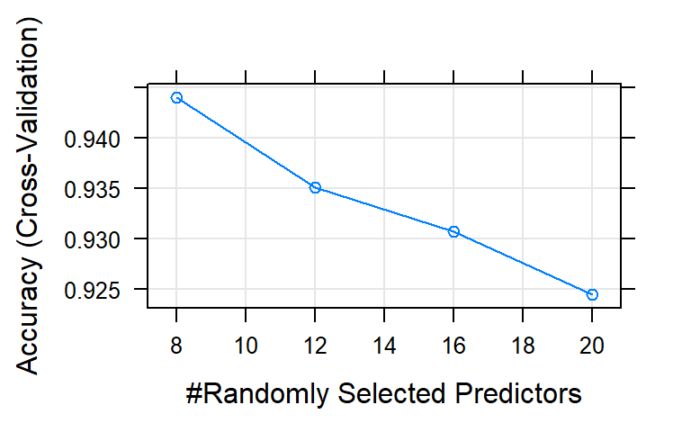

#### **Apply model to the test set**

```
##  Accuracy     Kappa
## 0.9546667 0.9495956
```

Nous avons une faible taux d’erreur de validation et elle est équivalant à l’erreur d’apprentissage.

#### **Resultat de la prédiction**

```
##                         Durée  Accuracy Taux.Erreur
## Random Forest   8.021825 secs 0.9546667  0.04533333
```

Resultats Random Forest

|  | Durée | Accuracy | Taux.Erreur |
| --- | --- | --- | --- |
| Random Forest | 8.021825 secs | 0.9546667 | 0.0453333 |

Nous avons une bonne accuracy pour la prédiction mais le temps d’excution est long.

### Neural Networks/reseau de neurones

- size (#Hidden Units)
  - decay (Weight Decay)

```
## Neural Network
##
## 1125 samples
##  240 predictor
##   10 classes: '0', '1', '2', '3', '4', '5', '6', '7', '8', '9'
##
## No pre-processing
## Resampling: Cross-Validated (5 fold)
## Summary of sample sizes: 899, 900, 900, 902, 899
## Resampling results across tuning parameters:
##
##   size  decay  Accuracy   Kappa
##   1      0.2   0.1982072  0.1085044
##   1      0.5   0.2044136  0.1135094
##   1      0.8   0.2061953  0.1180197
```

[output cut: 70 more lines]

```
## Best parameter pour size est : 3
```

```
## Best parameter pour decay  est : 3
```

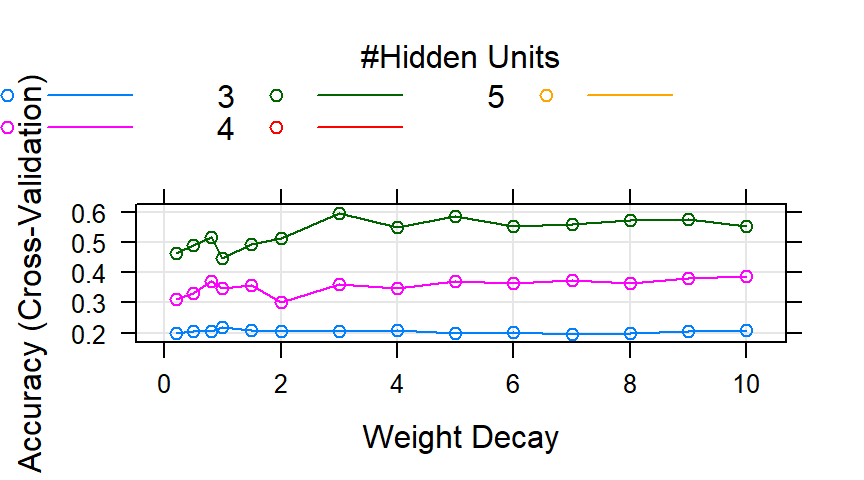

[figure not shown]

#### **Apply model to the test set**

```
##  Accuracy     Kappa
## 0.6026667 0.5597759
```

```
## Confusion Matrix and Statistics
##
##           Reference
## Prediction  0  1  2  3  4  5  6  7  8  9
##          0  0  0  0  1  0  0  1  0  0  0
##          1  0 30  4  0  1  1  0  1  0  1
##          2  1  1 30  0  0  0  0  0  0  0
##          3  1  1  1 34  0 31 22  3  0  0
##          4  1  2  0  0 32  1  5  0  2  0
##          5  1  0  0  1  0  0  3  0  0  0
##          6  0  0  0  0  0  2  4  0  0  0
##          7  0  1  3  2  0  4  0 28  0  0
##          8 39  0  0  0  0  1  2  0 33  2
##          9  1  2  1  0  0  0  0  1  1 35
##
## Overall Statistics
##
##                Accuracy : 0.6027
##                  95% CI : (0.5512, 0.6525)
##     No Information Rate : 0.1173
##     P-Value [Acc > NIR] : < 2.2e-16
##
##                   Kappa : 0.5598
##
##  Mcnemar's Test P-Value : NA
##
## Statistics by Class:
##
##                      Class: 0 Class: 1 Class: 2 Class: 3 Class: 4 Class: 5
## Sensitivity          0.000000  0.81081  0.76923  0.89474  0.96970  0.00000
## Specificity          0.993958  0.97633  0.99405  0.82493  0.96784  0.98507
## Pos Pred Value       0.000000  0.78947  0.93750  0.36559  0.74419  0.00000
## Neg Pred Value       0.882038  0.97923  0.97376  0.98582  0.99699  0.89189
## Prevalence           0.117333  0.09867  0.10400  0.10133  0.08800  0.10667
## Detection Rate       0.000000  0.08000  0.08000  0.09067  0.08533  0.00000
## Detection Prevalence 0.005333  0.10133  0.08533  0.24800  0.11467  0.01333
## Balanced Accuracy    0.496979  0.89357  0.88164  0.85983  0.96877  0.49254
##                      Class: 6 Class: 7 Class: 8 Class: 9
## Sensitivity           0.10811  0.84848   0.9167  0.92105
## Specificity           0.99408  0.97076   0.8702  0.98220
## Pos Pred Value        0.66667  0.73684   0.4286  0.85366
## Neg Pred Value        0.91057  0.98516   0.9899  0.99102
## Prevalence            0.09867  0.08800   0.0960  0.10133
## Detection Rate        0.01067  0.07467   0.0880  0.09333
## Detection Prevalence  0.01600  0.10133   0.2053  0.10933
## Balanced Accuracy     0.55110  0.90962   0.8934  0.95162
```

#### Plus proche voisins KNN

```
## Time difference of 1.249782 secs
```

```
## k-Nearest Neighbors
##
## 1125 samples
##   40 predictor
##   10 classes: '0', '1', '2', '3', '4', '5', '6', '7', '8', '9'
##
## No pre-processing
## Resampling: Cross-Validated (10 fold)
## Summary of sample sizes: 1012, 1012, 1013, 1012, 1013, 1014, ...
## Resampling results across tuning parameters:
##
##   k   Accuracy   Kappa
##    1  0.9733399  0.9703721
##    4  0.9733716  0.9704072
##    7  0.9688910  0.9654280
##   10  0.9617796  0.9575240
##   13  0.9591325  0.9545800
##
## Accuracy was used to select the optimal model using the largest value.
## The final value used for the model was k = 4.
```

```
## Best parameter pour k est : 4
```

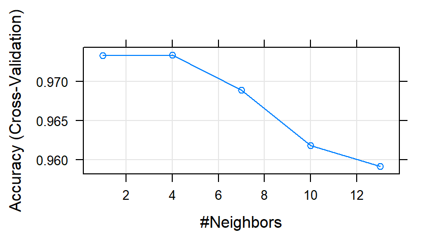

[figure not shown]

#### **Apply model to the test set**

```
##  Accuracy     Kappa
## 0.9733333 0.9703452
```

```
## Confusion Matrix and Statistics
##
##           Reference
## Prediction  0  1  2  3  4  5  6  7  8  9
##          0 43  0  0  0  0  0  0  0  1  0
##          1  0 36  0  0  0  1  0  0  0  0
##          2  0  0 39  0  0  0  0  1  0  0
##          3  1  0  0 38  0  1  0  0  1  0
##          4  0  0  0  0 33  0  0  0  0  0
##          5  0  1  0  0  0 38  2  0  0  0
##          6  0  0  0  0  0  0 34  0  0  0
##          7  0  0  0  0  0  0  0 32  0  0
##          8  0  0  0  0  0  0  1  0 34  0
##          9  0  0  0  0  0  0  0  0  0 38
##
## Overall Statistics
##
##                Accuracy : 0.9733
##                  95% CI : (0.9515, 0.9871)
##     No Information Rate : 0.1173
##     P-Value [Acc > NIR] : < 2.2e-16
##
##                   Kappa : 0.9703
##
##  Mcnemar's Test P-Value : NA
##
## Statistics by Class:
##
##                      Class: 0 Class: 1 Class: 2 Class: 3 Class: 4 Class: 5
## Sensitivity            0.9773  0.97297   1.0000   1.0000    1.000   0.9500
## Specificity            0.9970  0.99704   0.9970   0.9911    1.000   0.9910
## Pos Pred Value         0.9773  0.97297   0.9750   0.9268    1.000   0.9268
## Neg Pred Value         0.9970  0.99704   1.0000   1.0000    1.000   0.9940
## Prevalence             0.1173  0.09867   0.1040   0.1013    0.088   0.1067
## Detection Rate         0.1147  0.09600   0.1040   0.1013    0.088   0.1013
## Detection Prevalence   0.1173  0.09867   0.1067   0.1093    0.088   0.1093
## Balanced Accuracy      0.9871  0.98501   0.9985   0.9955    1.000   0.9705
##                      Class: 6 Class: 7 Class: 8 Class: 9
## Sensitivity           0.91892  0.96970  0.94444   1.0000
## Specificity           1.00000  1.00000  0.99705   1.0000
## Pos Pred Value        1.00000  1.00000  0.97143   1.0000
## Neg Pred Value        0.99120  0.99708  0.99412   1.0000
## Prevalence            0.09867  0.08800  0.09600   0.1013
## Detection Rate        0.09067  0.08533  0.09067   0.1013
## Detection Prevalence  0.09067  0.08533  0.09333   0.1013
## Balanced Accuracy     0.95946  0.98485  0.97075   1.0000
```

#### **Confusion Table**

Resultats KNN

|  | Durée | Accuracy | Taux.Erreur |
| --- | --- | --- | --- |
| KNN | 1.249782 secs | 0.9733333 | 0.0266667 |

### Perceptron multicouche

```
## Multi-Layer Perceptron, with multiple layers
##
## 1125 samples
##  240 predictor
##   10 classes: '0', '1', '2', '3', '4', '5', '6', '7', '8', '9'
##
## No pre-processing
## Resampling: Cross-Validated (5 fold)
## Summary of sample sizes: 899, 900, 900, 902, 899
## Resampling results:
##
##   Accuracy   Kappa
##   0.9715311  0.9683643
##
## Tuning parameter 'layer1' was held constant at a value of 240
## Tuning
##  parameter 'layer2' was held constant at a value of 10
## Tuning
##  parameter 'layer3' was held constant at a value of 0
```

#### **Apply model to the test set**

```
##  Accuracy     Kappa
## 0.9680000 0.9644198
```

```
## Confusion Matrix and Statistics
##
##           Reference
## Prediction  0  1  2  3  4  5  6  7  8  9
##          0 43  0  0  0  0  0  0  0  0  0
##          1  1 35  0  1  0  2  0  0  1  0
##          2  0  0 38  0  0  0  0  0  0  0
##          3  0  0  0 37  0  1  0  0  0  0
##          4  0  0  0  0 33  0  0  0  0  0
##          5  0  1  0  0  0 37  2  0  0  0
##          6  0  1  0  0  0  0 35  0  0  0
##          7  0  0  1  0  0  0  0 32  0  0
##          8  0  0  0  0  0  0  0  0 35  0
##          9  0  0  0  0  0  0  0  1  0 38
##
## Overall Statistics
##
##                Accuracy : 0.968
##                  95% CI : (0.9448, 0.9834)
##     No Information Rate : 0.1173
##     P-Value [Acc > NIR] : < 2.2e-16
##
##                   Kappa : 0.9644
##
##  Mcnemar's Test P-Value : NA
##
## Statistics by Class:
##
##                      Class: 0 Class: 1 Class: 2 Class: 3 Class: 4 Class: 5
## Sensitivity            0.9773  0.94595   0.9744  0.97368    1.000  0.92500
## Specificity            1.0000  0.98521   1.0000  0.99703    1.000  0.99104
## Pos Pred Value         1.0000  0.87500   1.0000  0.97368    1.000  0.92500
## Neg Pred Value         0.9970  0.99403   0.9970  0.99703    1.000  0.99104
## Prevalence             0.1173  0.09867   0.1040  0.10133    0.088  0.10667
## Detection Rate         0.1147  0.09333   0.1013  0.09867    0.088  0.09867
## Detection Prevalence   0.1147  0.10667   0.1013  0.10133    0.088  0.10667
## Balanced Accuracy      0.9886  0.96558   0.9872  0.98536    1.000  0.95802
##                      Class: 6 Class: 7 Class: 8 Class: 9
## Sensitivity           0.94595  0.96970  0.97222   1.0000
## Specificity           0.99704  0.99708  1.00000   0.9970
## Pos Pred Value        0.97222  0.96970  1.00000   0.9744
## Neg Pred Value        0.99410  0.99708  0.99706   1.0000
## Prevalence            0.09867  0.08800  0.09600   0.1013
## Detection Rate        0.09333  0.08533  0.09333   0.1013
## Detection Prevalence  0.09600  0.08800  0.09333   0.1040
## Balanced Accuracy     0.97149  0.98339  0.98611   0.9985
```